# report

Pavel Vychyk

11/7/2021

#### Check for required packages

```r
pckages <- c('data.table', 'tidyr', 'dplyr', 'ggplot2', 'nortest', 'knitr')
for(package in pckages) {
  if(!require(package, character.only = T)) {
    install.packages(package, dependencies = T)
    library(package)
  }
}
```

#### Load required libraries

```r
library(data.table)
library(tidyr)
library(dplyr)
library(ggplot2)
library(nortest)
library(knitr)
```

#### provide the path to the data

```r
input_folder <- "/home/aither/institute-for-bioinformatics/r-studio/project-olympics/athlete_events/"
extension = "csv"
```

#### import function

```r
data_import <- function(input_folder, extension){
  files <- list.files(paste(input_folder), full.names = T, pattern = paste0(".+",extension,"$"))
  print(files)
  rbindlist(lapply(files, fread), fill = T)
}

olympics_data <- data_import(input_folder, "csv")
```

#### 2. correct data - some rows have incomplete entries, due to fread import - correct with NA?

Some variable have anomalities, and NA values. Further we proceed with filtering values in functions via !is.na() etc.

```r
apply(olympics_data[, 3], 2, FUN = unique)
```

```
##      Sex
## [1,] "M"
## [2,] "F"
## [3,] "G"
```

#### 3. get youngest athletes on Olympics 1992

```r
olympics_data[olympics_data$Year == 1992, .SD[which.min(Age)], by = Sex]
```

```
##    Sex    ID                            Name Age Height Weight    Team NOC
## 1:   M 37333 Carlos Bienvenido Front Barrera  11     NA     NA   Spain ESP
## 2:   F 60854                      Judit Kiss  12    171     57 Hungary HUN
##          Games Year Season      City    Sport
## 1: 1992 Summer 1992 Summer Barcelona   Rowing
## 2: 1992 Summer 1992 Summer Barcelona Swimming
##                                    Event Medal
## 1:             Rowing Men's Coxed Eights  <NA>
## 2: Swimming Women's 400 metres Freestyle  <NA>
```

#### 4. Calculate mean and standard deviation for Height in each Sex category

```r
olympics_data %>%
  filter(!is.na(Height) & Sex %in% c("M","F")) %>%
  group_by(Sex) %>%
  summarize(mean(Height), sd(Height))
```

```
## # A tibble: 2 × 3
##   Sex   `mean(Height)` `sd(Height)`
##   <chr>          <dbl>        <dbl>
## 1 F               168.         8.80
## 2 M               179.         9.36
```

```r
olympics_data %>%
  filter(!is.na(Height) & Sex == "F" & Year == 2006) %>%
  summarize(mean(Height), sd(Height))
```

```
##   mean(Height) sd(Height)
## 1     166.8389   5.821344
```

#### 6. The most heavy athlete sports

```r
olympics_data %>%
  filter(!is.na(Weight) & Year == 2006 & Sex == "M") %>%
  filter(Weight == max(Weight)) %>% select(Name,Weight,Sport)
```

```
##                 Name Weight    Sport
## 1: Patrick R. Antaki    127 Skeleton
```

#### 7. Woman’s gold count from 1980 to 2010

```r
olympics_data %>%
  filter( Sex == "F" & Year >= 1980 & Year <= 2010 & Medal == "Gold") %>%
  summarise(n = n())
```

```
##      n
## 1 2249
```

#### 8. John Aalberg participation in Olympics

```r
olympics_data %>%
  filter( Name == "John Aalberg") %>% group_by(Year) %>%
  summarise(n = n())
```

```
## # A tibble: 2 × 2
##    Year     n
##   <int> <int>
## 1  1992     4
## 2  1994     4
```

#### 9. Age groups of athletes on Olympics 2008

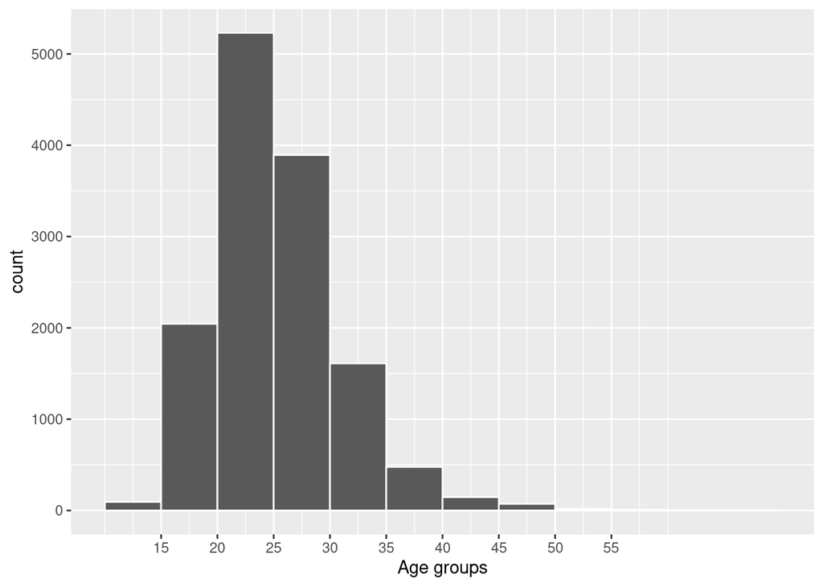

```r
A2008 <- olympics_data %>%
  filter( Year == 2008 & !is.na(Age)) %>% select(Age)
ggplot(data=A2008, aes(x=A2008$Age)) +
  geom_histogram(binwidth=5,
                 aes(col=I("white")),
                 closed = "right",
                 center = 2.5) +
  scale_x_continuous(xlab("Age groups"),
                     breaks=seq(15,55, by = 5))
```

#### 10. Sports number difference between 2002 and 1994

```r
diff_sports <- olympics_data %>%
  filter(Year %in% c(1994,2002)) %>%
  group_by(Year) %>%
  summarise(count = n_distinct(Sport))
```

[output not shown]

#### 11. Top 3 for medals

```r
olympics_data %>%
  filter(!is.na(Medal) & !is.na(Season) & !is.na(Team)) %>%
  group_by(Season,Medal,Team) %>%
  summarise(n = n()) %>%
  slice_max(order_by = n, n = 3)
```

```
## # A tibble: 18 × 4
## # Groups:   Season, Medal [6]
##    Season Medal  Team              n
##    <chr>  <chr>  <chr>         <int>
##  1 Summer Bronze United States  1112
##  2 Summer Bronze Germany         610
##  3 Summer Bronze Soviet Union    596
##  4 Summer Gold   United States  2333
##  5 Summer Gold   Soviet Union    830
##  6 Summer Gold   Germany         564
##  7 Summer Silver United States  1241
##  8 Summer Silver Soviet Union    635
##  9 Summer Silver Great Britain   576
## 10 Winter Bronze Finland         215
## 11 Winter Bronze Sweden          177
## 12 Winter Bronze Norway          127
## 13 Winter Gold   Canada          289
## 14 Winter Gold   Soviet Union    228
## 15 Winter Gold   Norway          151
## 16 Winter Silver United States   271
## 17 Winter Silver Canada          189
## 18 Winter Silver Norway          165
```

#### 12. Calculate Height_z_scores for Height variable

```r
olympics_data %>%
  filter(!is.na(Height)) %>%
  mutate(Height_z_scores = (Height - mean(Height)) / sd(Height)) %>%
  mutate
```

```
##             ID                     Name Sex Age Height Weight        Team NOC
##      1:      1                A Dijiang   M  24    180     80       China CHN
##      2:      2                 A Lamusi   M  23    170     60       China CHN
##      3:      5 Christine Jacoba Aaftink   F  21    185     82 Netherlands NED
##      4:      5 Christine Jacoba Aaftink   F  21    185     82 Netherlands NED
##      5:      5 Christine Jacoba Aaftink   F  25    185     82 Netherlands NED
##     ---
## 210934: 135569               Andrzej ya   M  29    179     89    Poland-1 POL
## 210935: 135570                 Piotr ya   M  27    176     59      Poland POL
## 210936: 135570                 Piotr ya   M  27    176     59      Poland POL
## 210937: 135571       Tomasz Ireneusz ya   M  30    185     96      Poland POL
## 210938: 135571       Tomasz Ireneusz ya   M  34    185     96      Poland POL
##               Games Year Season           City         Sport
##      1: 1992 Summer 1992 Summer      Barcelona    Basketball
##      2: 2012 Summer 2012 Summer         London          Judo
```

[output cut: 21 more lines]

#### 13. Min-max normalization

```r
olympics_data %>%
  filter(!is.na(Height)) %>%
  mutate(Height_min_max_scaled = (Height - min(Height))/(max(Height)+min(Height))) %>%
  mutate(Height_min_max_scaled = round(Height_min_max_scaled,2)) %>%
  head()
```

```
##    ID                     Name Sex Age Height Weight        Team NOC
## 1:  1                A Dijiang   M  24    180     80       China CHN
## 2:  2                 A Lamusi   M  23    170     60       China CHN
## 3:  5 Christine Jacoba Aaftink   F  21    185     82 Netherlands NED
## 4:  5 Christine Jacoba Aaftink   F  21    185     82 Netherlands NED
## 5:  5 Christine Jacoba Aaftink   F  25    185     82 Netherlands NED
## 6:  5 Christine Jacoba Aaftink   F  25    185     82 Netherlands NED
##          Games Year Season        City         Sport
## 1: 1992 Summer 1992 Summer   Barcelona    Basketball
## 2: 2012 Summer 2012 Summer      London          Judo
## 3: 1988 Winter 1988 Winter     Calgary Speed Skating
## 4: 1988 Winter 1988 Winter     Calgary Speed Skating
## 5: 1992 Winter 1992 Winter Albertville Speed Skating
## 6: 1992 Winter 1992 Winter Albertville Speed Skating
##                                 Event Medal Height_min_max_scaled
## 1:        Basketball Men's Basketball  <NA>                  0.11
## 2:       Judo Men's Extra-Lightweight  <NA>                  0.09
## 3:   Speed Skating Women's 500 metres  <NA>                  0.12
## 4: Speed Skating Women's 1,000 metres  <NA>                  0.12
## 5:   Speed Skating Women's 500 metres  <NA>                  0.12
## 6: Speed Skating Women's 1,000 metres  <NA>                  0.12
```

#### 14. Comparison of height for men and women participated in

#### winter Olympics

Firstly, we must check our data for normality. I’ve used to Shapiro-Wilk and Anderson-Darling normality tests. Although the Q-Q Plots were used to provide additional support to the tests evidences.

```r
w_men_height <- olympics_data %>%
  filter(!is.na(Height) & is.numeric(Height) & Sex == "M" & Season == "Winter") %>%
  select(Height)
w_women_height <- olympics_data %>%
  filter(!is.na(Height) & Sex == "F" & Season == "Winter") %>%
  select(Height)

shapiro.test(w_men_height$Height[0:3000])
```

```
##
##  Shapiro-Wilk normality test
##
## data:  w_men_height$Height[0:3000]
## W = 0.99524, p-value = 3.056e-08
```

```r
ad.test(w_men_height$Height)
```

```
##
##  Anderson-Darling normality test
##
## data:  w_men_height$Height
## A = 47.721, p-value < 2.2e-16
```

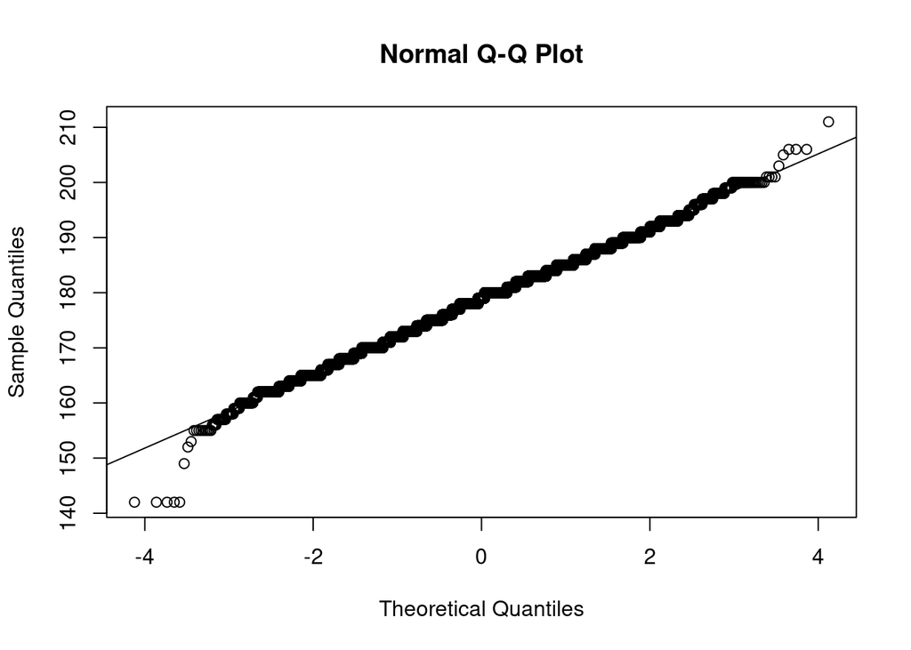

```r
qqnorm(w_men_height$Height)
qqline(w_men_height$Height)
```

```r
shapiro.test(w_women_height$Height[0:3000])
```

```
##
##  Shapiro-Wilk normality test
##
## data:  w_women_height$Height[0:3000]
## W = 0.9939, p-value = 6.979e-10
```

```r
ad.test(w_women_height$Height)
```

```
##
##  Anderson-Darling normality test
##
## data:  w_women_height$Height
## A = 21.063, p-value < 2.2e-16
```

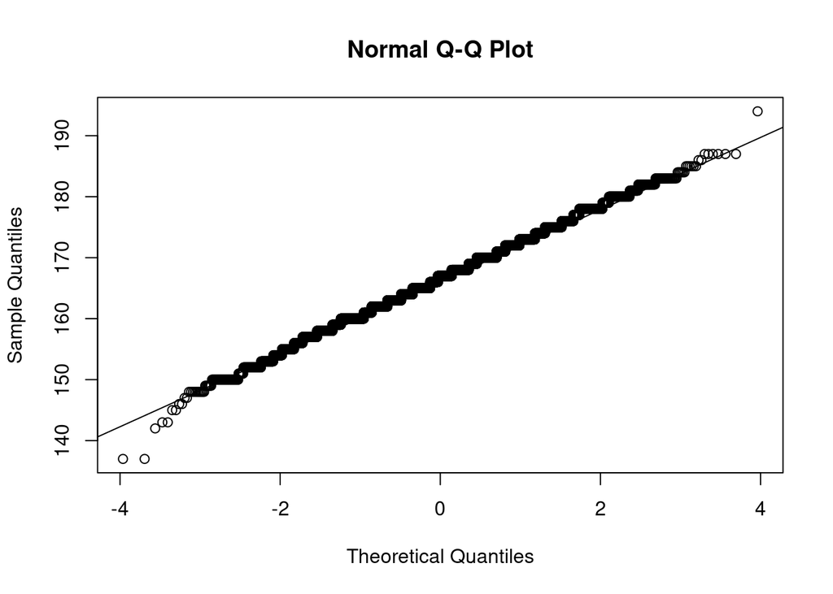

```r
qqnorm(w_women_height$Height)
qqline(w_women_height$Height)
```

Despite statistical tests reject hypothesis for normality in our data, plots and provide enough information to use both parametric and non-parametric comparison tests: Student’s t-Test and Mann-Whitney test. Both support the existence of difference in height for men in women in the sample, rejecting the Null-hypothesis

```r
t.test(w_men_height$Height, w_women_height$Height, alternative = c("two.sided"))
```

```
##
##  Welch Two Sample t-test
##
## data:  w_men_height$Height and w_women_height$Height
## t = 184.8, df = 29342, p-value < 2.2e-16
## alternative hypothesis: true difference in means is not equal to 0
## 95 percent confidence interval:
##  12.01208 12.26962
## sample estimates:
## mean of x mean of y
##  178.6691  166.5283
```

```r
wilcox.test(w_men_height$Height, w_women_height$Height, alternative = c("two.sided"), paired = F)
```

```
##
##  Wilcoxon rank sum test with continuity correction
##
## data:  w_men_height$Height and w_women_height$Height
## W = 329606937, p-value < 2.2e-16
## alternative hypothesis: true location shift is not equal to 0
```

#### 15. Team and medal correlation

To measure the association between team and medals we use Spearman correlation coefficient for ranks.

```r
f_olympics_data <- olympics_data %>%
  filter(!is.na(Team) & !is.na(Medal))

test_cor<-cor.test(rank(f_olympics_data$Team), rank(f_olympics_data$Medal), method = 'spearman')
```